# Многофакторный анализ

Цепелева И.А.

2023-01-18

ЗАДАНИЕ 1  
Диагональ ковариационной матрицы - это дисперсии каждой из случайных величин.  
Другие значения в матрице представляют собой ковариации между различными субъектами.

а)

```r
library(mvtnorm)
f <- rmvnorm(n=100, mean = c(85.5, 5.4), sigma = matrix(c(13.25^2, 0.6*13.25*1.45, 0.6*13.25*1.45, 1.45^2), ncol = 2))
f <- as.data.frame(f)

summary(lm(f$V1 ~ f$V2))
```

```
##
## Call:
## lm(formula = f$V1 ~ f$V2)
##
## Residuals:
##      Min       1Q   Median       3Q      Max
## -27.8213  -5.5285  -0.8127   6.3555  29.0075
##
## Coefficients:
##             Estimate Std. Error t value Pr(>|t|)
## (Intercept)  56.9803     3.5718  15.953  < 2e-16 ***
## f$V2          5.0663     0.6105   8.298 5.83e-13 ***
## ---
## Signif. codes:  0 '***' 0.001 '**' 0.01 '*' 0.05 '.' 0.1 ' ' 1
##
## Residual standard error: 9.982 on 98 degrees of freedom
## Multiple R-squared:  0.4127, Adjusted R-squared:  0.4067
## F-statistic: 68.86 on 1 and 98 DF,  p-value: 5.835e-13
```

```r
#проверим, как среднее влияет на полученные оценки
f_mean <- as.data.frame(rmvnorm(n=100, mean = c(171, 10.8), sigma = matrix(c(13.25^2, 0.6*13.25*1.45, 0.6*13.25*1.45, 1.45^2), ncol = 2)))
summary(lm(f_mean$V1 ~ f_mean$V2))
```

```
##
## Call:
## lm(formula = f_mean$V1 ~ f_mean$V2)
##
## Residuals:
##      Min       1Q   Median       3Q      Max
## -25.5730  -6.7191   0.4191   6.6379  31.5972
##
## Coefficients:
##             Estimate Std. Error t value Pr(>|t|)
## (Intercept) 121.8884     8.0994  15.049  < 2e-16 ***
## f_mean$V2     4.6050     0.7509   6.132 1.83e-08 ***
## ---
## Signif. codes:  0 '***' 0.001 '**' 0.01 '*' 0.05 '.' 0.1 ' ' 1
##
## Residual standard error: 11.51 on 98 degrees of freedom
## Multiple R-squared:  0.2773, Adjusted R-squared:  0.2699
## F-statistic:  37.6 on 1 and 98 DF,  p-value: 1.827e-08
```

```r
#влияние дисперсии
f_disp <- as.data.frame(rmvnorm(n=100, mean = c(85.5, 5.4), sigma = matrix(c(4*13.25^2, 0.6*2*13.25*1.45, 0.6*2*13.25*1.45, 1.45^2), ncol = 2)))
summary(lm(f_disp$V1 ~ f_disp$V2))
```

```
##
## Call:
## lm(formula = f_disp$V1 ~ f_disp$V2)
##
## Residuals:
##     Min      1Q  Median      3Q     Max
## -55.571 -14.913   0.708  14.643  45.709
##
## Coefficients:
##             Estimate Std. Error t value Pr(>|t|)
## (Intercept)   27.095      8.409   3.222  0.00173 **
## f_disp$V2     10.612      1.494   7.105 1.95e-10 ***
## ---
## Signif. codes:  0 '***' 0.001 '**' 0.01 '*' 0.05 '.' 0.1 ' ' 1
##
## Residual standard error: 22.32 on 98 degrees of freedom
## Multiple R-squared:   0.34,  Adjusted R-squared:  0.3333
## F-statistic: 50.48 on 1 and 98 DF,  p-value: 1.947e-10
```

```r
#(Intercept) уменьшение оценки

#влияние корреляции
f_cor <- as.data.frame(rmvnorm(n=100, mean = c(85.5, 5.4), sigma = matrix(c(13.25^2, 0.3*13.25*1.45, 0.3*13.25*1.45, 1.45^2), ncol = 2)))
summary(lm(f_cor$V1 ~ f_cor$V2))
```

```
##
## Call:
## lm(formula = f_cor$V1 ~ f_cor$V2)
##
## Residuals:
##     Min      1Q  Median      3Q     Max
## -30.002  -7.610  -1.114   7.877  38.788
##
## Coefficients:
##             Estimate Std. Error t value Pr(>|t|)
## (Intercept)  71.7916     4.6045  15.592  < 2e-16 ***
## f_cor$V2      2.3890     0.8048   2.968  0.00376 **
## ---
## Signif. codes:  0 '***' 0.001 '**' 0.01 '*' 0.05 '.' 0.1 ' ' 1
##
## Residual standard error: 13.67 on 98 degrees of freedom
## Multiple R-squared:  0.08249,    Adjusted R-squared:  0.07313
## F-statistic: 8.811 on 1 and 98 DF,  p-value: 0.003764
```

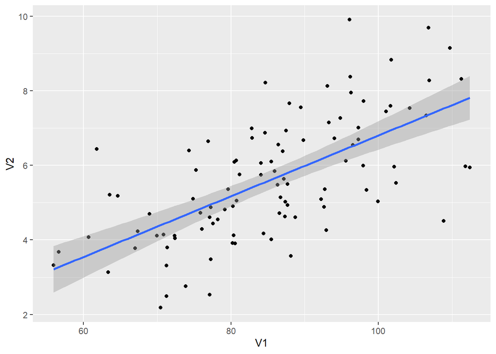

```r
#снижение перед f_cor$V2

library(ggplot2)
ggplot()+
  geom_point(data=f, aes(x=V1, y=V2)) +
  geom_smooth(data=f, aes(x=V1, y=V2), method=lm)
```

б) Гипотезу о нормальном распределении остатков проверяем с помощью теста Шапиро-Уилка

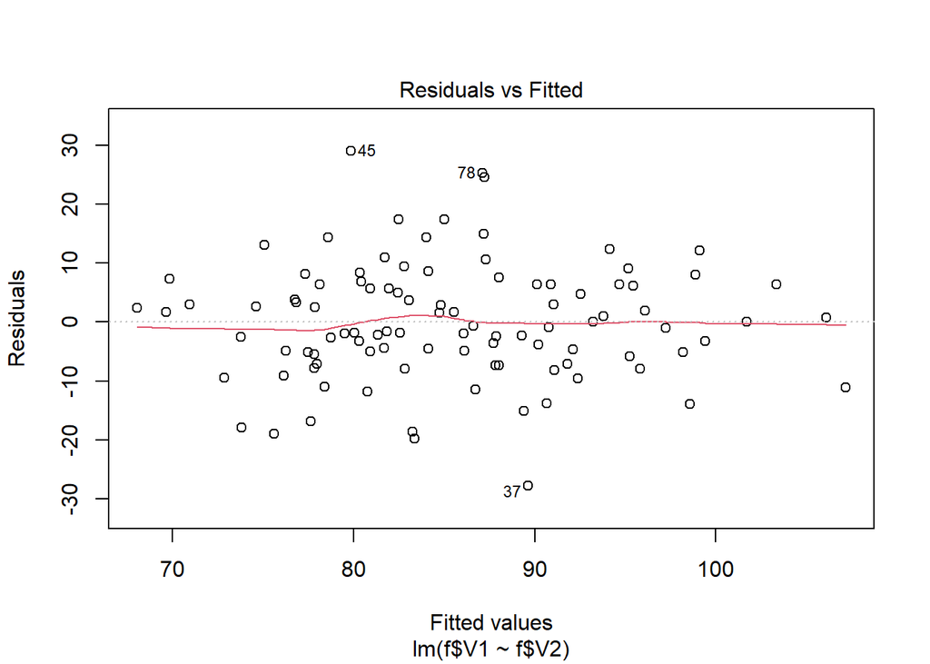

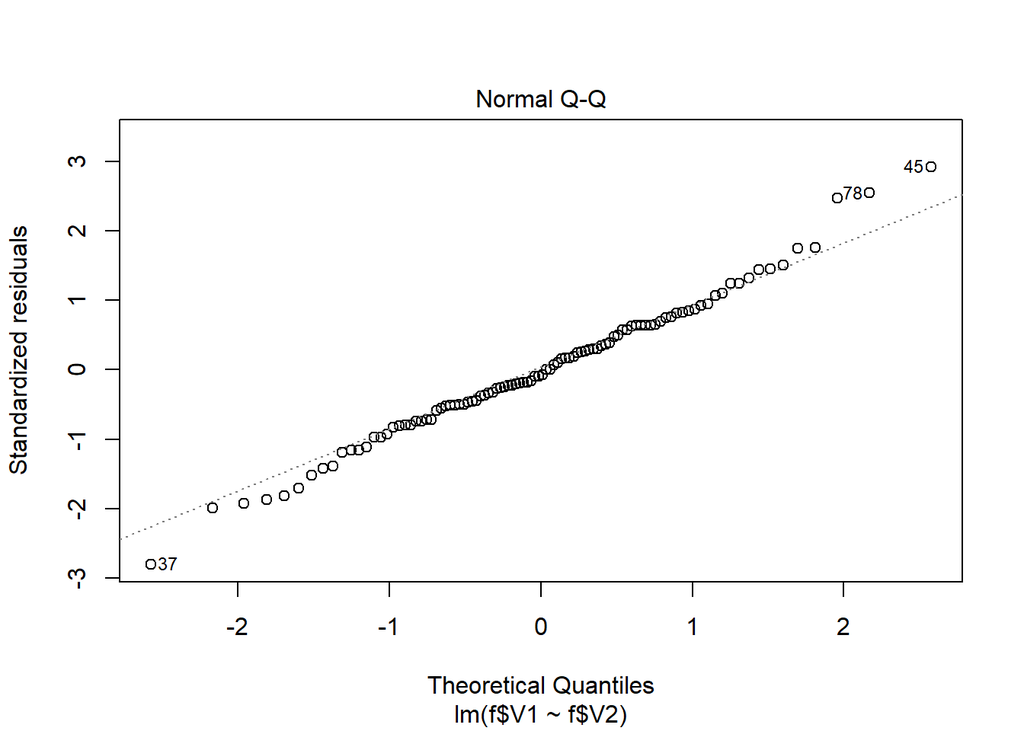

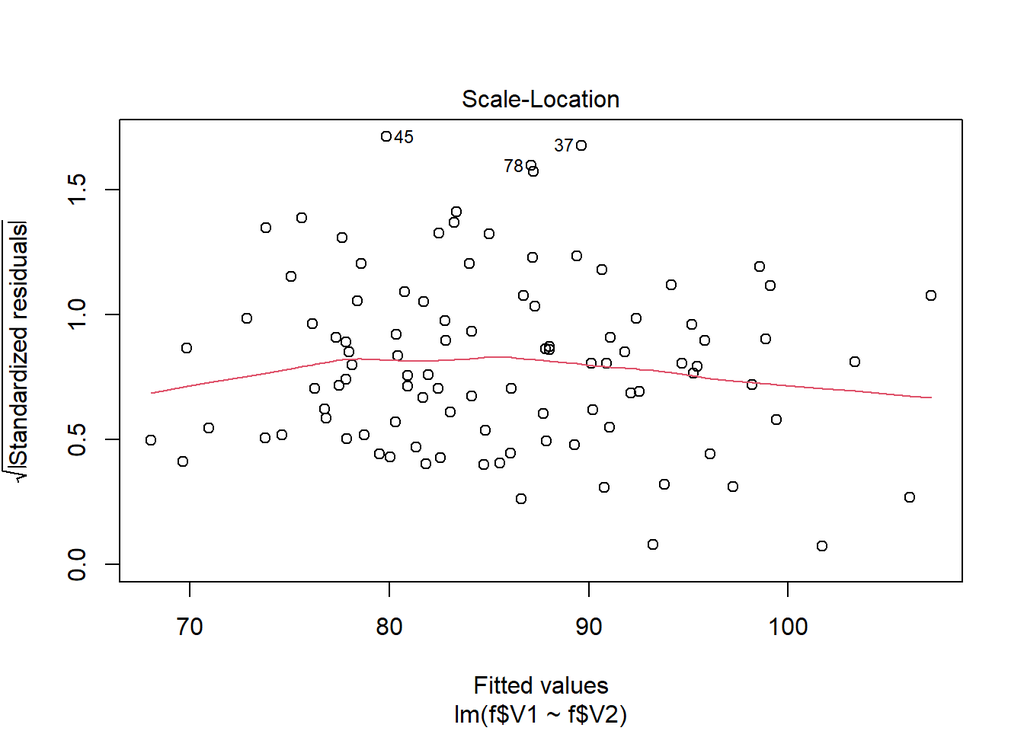

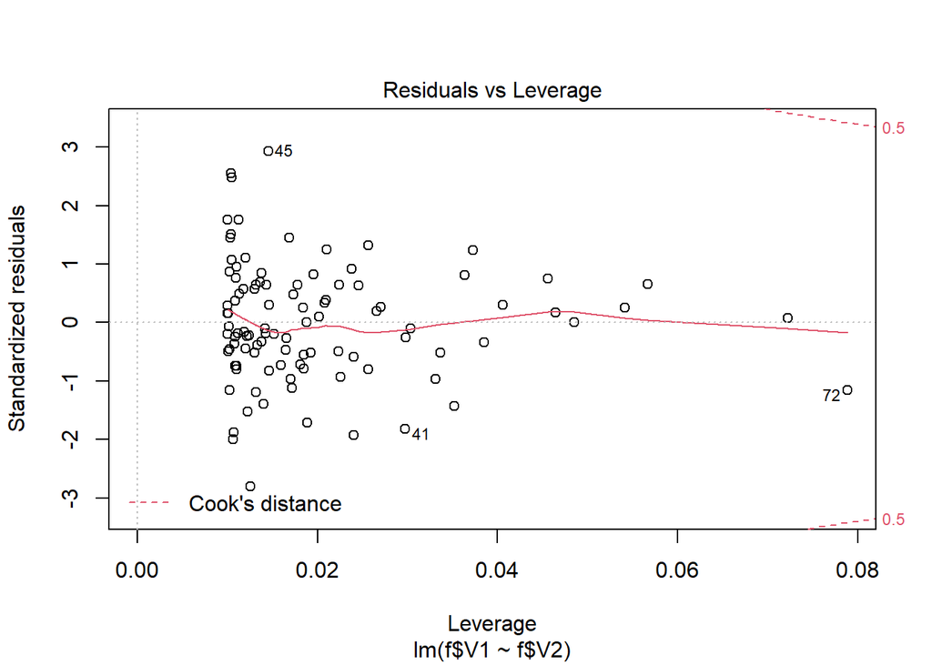

```r
plot(lm(f$V1 ~ f$V2))
```

```r
fit <- lm(f$V1 ~ f$V2)
shapiro.test(residuals(fit,type="response"))
```

```
##
##  Shapiro-Wilk normality test
##
## data:  residuals(fit, type = "response")
## W = 0.99023, p-value = 0.6831
```

```r
f$V3 <- rnorm(100, 0, 100)
summary(lm(f$V1 ~ f$V2 + f$V3))
```

```
##
## Call:
## lm(formula = f$V1 ~ f$V2 + f$V3)
##
## Residuals:
##     Min      1Q  Median      3Q     Max
## -28.183  -5.500  -0.814   6.244  28.864
##
## Coefficients:
##              Estimate Std. Error t value Pr(>|t|)
## (Intercept) 56.902854   3.605520  15.782  < 2e-16 ***
## f$V2         5.078004   0.615667   8.248 7.95e-13 ***
## f$V3         0.002456   0.010853   0.226    0.821
## ---
## Signif. codes:  0 '***' 0.001 '**' 0.01 '*' 0.05 '.' 0.1 ' ' 1
##
## Residual standard error: 10.03 on 97 degrees of freedom
## Multiple R-squared:  0.413,  Adjusted R-squared:  0.4009
## F-statistic: 34.12 on 2 and 97 DF,  p-value: 6.013e-12
```

Коэффициент детерминации увеличился во всех симуляциях,а модифицированный коэффициент детерминации - то увеличивался, то уменьшался.  
!!! Значение коэффициента детерминации растет с увеличением числа регрессоров.

ЗАДАНИЕ 2

```r
x1 <- rnorm(50, 0, 100)
x2 <- x1*(1+rnorm(50, 0, 0.01))
x3 <- x1*(1+rnorm(50, 0, 0.05))
x4 <- x1 + rnorm(50, 0, 0.02)
x5 <- rnorm(50, 0, 0.01)+x3+x2

y = x1 + x2 + 2*x3 + x4 + 6*x5 + rnorm(50, 0, 1)
summary(lm(y~x1+x2+x3+x4+x5))
```

```
##
## Call:
## lm(formula = y ~ x1 + x2 + x3 + x4 + x5)
##
## Residuals:
##      Min       1Q   Median       3Q      Max
## -2.19273 -1.05819  0.08221  0.75644  2.60037
##
## Coefficients:
##             Estimate Std. Error t value Pr(>|t|)
## (Intercept)   0.1004     0.1899   0.529    0.600
## x1            2.9315    10.5688   0.277    0.783
## x2           18.8995    22.6318   0.835    0.408
## x3           19.5752    22.5484   0.868    0.390
## x4           -1.1936    10.6505  -0.112    0.911
## x5          -11.6065    22.5526  -0.515    0.609
##
## Residual standard error: 1.288 on 44 degrees of freedom
## Multiple R-squared:      1,  Adjusted R-squared:      1
## F-statistic: 1.395e+07 on 5 and 44 DF,  p-value: < 2.2e-16
```

```r
library(glmnet)
X <- matrix(c(x1, x2, x3, x4, x5), ncol = 5)

la.eq <- glmnet(X,y, family = 'gaussian', intercept = F, alpha = 1)
coef.glmnet(la.eq , s=0.2)
```

```
## 6 x 1 sparse Matrix of class "dgCMatrix"
##                    s1
## (Intercept)  .
## V1          10.195433
## V2           1.043565
## V3           1.912517
## V4           .
## V5           1.726865
```

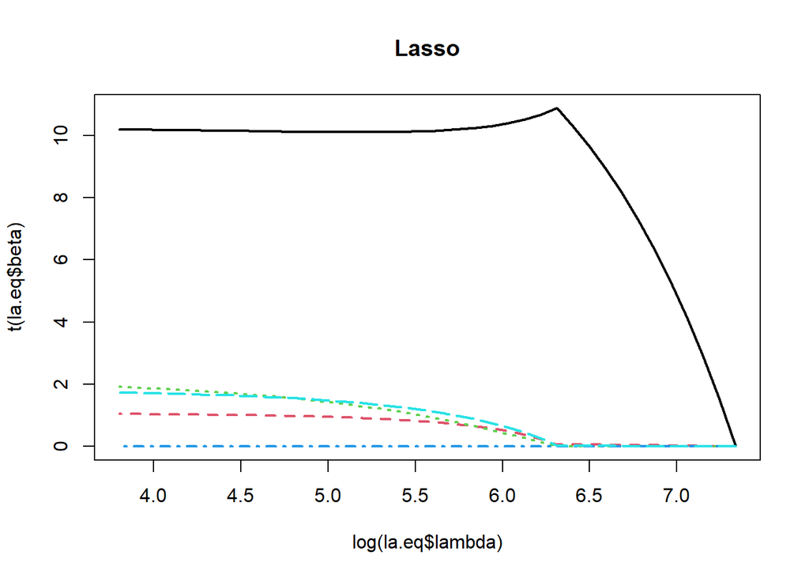

```r
matplot(log(la.eq$lambda), t(la.eq$beta), type='l', main='Lasso', lwd=2)
```

```r
predict(la.eq, X, type = "coefficients", s=0.2)
```

```
## 6 x 1 sparse Matrix of class "dgCMatrix"
##                    s1
## (Intercept)  .
## V1          10.195433
## V2           1.043565
## V3           1.912517
## V4           .
## V5           1.726865
```

Значения коэффициентов сильно изменились. Высокий коэффициент только при х1, что обусловлено сильной зависимостью других предикторов именно от х1

Пример сильно зависимых показателей, которые могут быть связаны регрессионным соотношением: высвобождение лекарственного средства из липосом в ЖКТ, зависимость концентрации препарата от времени

ЗАДАНИЕ 3

```r
library(dplyr)
s <- data.frame(Neu = rnorm(201, mean = 80, sd = 5) %>% round(0), Ly = rnorm(201, mean = 20, sd = 5)%>%round(0))

s$Sepsis <- ifelse(s$Neu/s$Ly < 3, 0, (s$Neu/s$Ly - 3)/6 )
s$Sepsis <- ifelse(s$Neu/s$Ly > 9, 1, s$Sepsis )
```

```r
summary(glm(Sepsis ~ Neu + Ly, s, family = gaussian))
```

```
##
## Call:
## glm(formula = Sepsis ~ Neu + Ly, family = gaussian, data = s)
##
## Deviance Residuals:
##      Min        1Q    Median        3Q       Max
## -0.07666  -0.05075  -0.03695   0.00952   0.35234
##
## Coefficients:
##              Estimate Std. Error t value Pr(>|t|)
## (Intercept)  0.407878   0.111017   3.674 0.000307 ***
## Neu          0.006056   0.001295   4.677 5.38e-06 ***
## Ly          -0.033404   0.001160 -28.794  < 2e-16 ***
## ---
## Signif. codes:  0 '***' 0.001 '**' 0.01 '*' 0.05 '.' 0.1 ' ' 1
##
## (Dispersion parameter for gaussian family taken to be 0.007000162)
##
##     Null deviance: 7.9965  on 200  degrees of freedom
## Residual deviance: 1.3860  on 198  degrees of freedom
## AIC: -421.94
##
## Number of Fisher Scoring iterations: 2
```

Какая вероятность для случайной величины Sepsis быть равной 1, если Neu = 90, а Ly = 15? Какую вероятность предсказывает ваша модель (воспользуйтесь функцией predict)?

```r
data <- data.frame(Neu = 90, Ly = 15)
predict(glm(Sepsis ~ Neu + Ly, s, family = gaussian), data)
```

```
##         1
## 0.4518945
```